# Recursos 13

9 actividades; 5 operarios; tres reglas de prioridad frente a Wiest-Levy

# Enunciado

Considere el proyecto cuyo cuadro de prelaciones, duraciones (semanas) y operarios necesarios se adjunta. Sólo se dispone de 5 operarios y las actividades no pueden interrumpirse una vez empezadas.

1. Calcule el calendario sin restricción de recursos y dibuje las cargas con los inicios más tempranos. ¿En qué semanas se superan los 5 operarios?

2. Programe el proyecto periodo a periodo con un planificador en paralelo: en cada semana se ordenan las actividades disponibles según una regla de prioridad y se van admitiendo mientras quepan en el límite. Aplique tres reglas: (a) menor holgura total, (b) menor duración (SPT) y (c) mayor número de operarios. Dé la duración con cada una.

3. Compare con el resultado del algoritmo de Wiest-Levy de la librería (`asignar`).

4. ¿Alguna regla garantiza la duración mínima? ¿Qué información usa la regla de la holgura que no usan las otras?

Tabla 1: Cuadro de datos del enunciado

| activity | predecessor | duration | resources |
| --- | --- | --- | --- |
| A | --- | 2 | 4 |
| B | --- | 3 | 1 |
| C | --- | 5 | 2 |
| D | A | 4 | 1 |
| E | A | 5 | 2 |
| F | B,C,D | 2 | 1 |
| G | E | 3 | 4 |
| H | F,G | 3 | 4 |
| I | F | 3 | 2 |

# Resolución

## Apartado 1

1. Calcule el calendario sin restricción de recursos y dibuje las cargas con los inicios más tempranos. ¿En qué semanas se superan los 5 operarios?

Cálculo de los tiempos mínimos y máximos de los nodos del grafo Roy paso a paso. El primer paso muestra el grafo resuelto; a partir del siguiente se calcula desde el principio (avance con los botones):

[figure not shown]

paso 0 de 24

[figure not shown]

Figura 1: Grafo Roy con tiempos y camino crítico

Tabla 2: Calendario sin restricción de recursos

[figure not shown]

ninguna celda (0 de 72)

[figure not shown]

Haz clic en un número de la tabla para ver cómo se calcula.

👆 **Interactivo:** haz clic en cualquier celda de la tabla para ver cómo se calcula (otro clic la deselecciona), o usa los botones y las flechas del teclado.

| Actividad | Duración | Inicio más temprano | Fin más temprano | Inicio más tardío | Fin más tardío | H total | H libre | H independiente |
| --- | --- | --- | --- | --- | --- | --- | --- | --- |
| A | 2 | 0 | 2 | 0 | 2 | 0 | 0 | 0 |
| B | 3 | 0 | 3 | 5 | 8 | 5 | 3 | 3 |
| C | 5 | 0 | 5 | 3 | 8 | 3 | 1 | 1 |
| D | 4 | 2 | 6 | 4 | 8 | 2 | 0 | 0 |
| E | 5 | 2 | 7 | 2 | 7 | 0 | 0 | 0 |
| F | 2 | 6 | 8 | 8 | 10 | 2 | 0 | 0 |
| G | 3 | 7 | 10 | 7 | 10 | 0 | 0 | 0 |
| H | 3 | 10 | 13 | 10 | 13 | 0 | 0 | 0 |
| I | 3 | 8 | 11 | 10 | 13 | 2 | 2 | 0 |

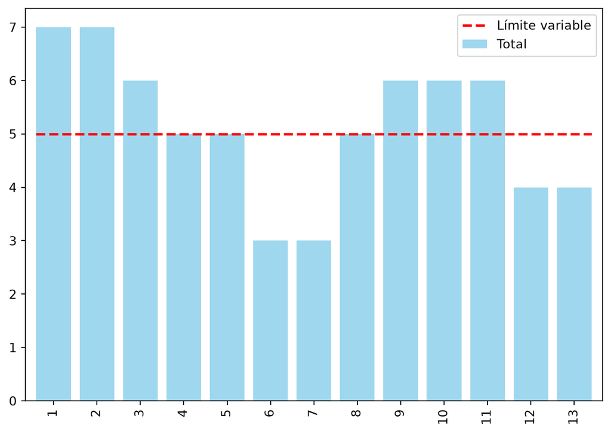

Figura 2: Cargas con los inicios más tempranos

**Respuesta:** sin límite el proyecto dura 13 semanas; con los inicios más tempranos se superan los 5 operarios en las semanas 1, 2, 3, 9, 10 y 11 (cargas 7, 7, 6, 6, 6, 6).

## Apartado 2

2. Programe el proyecto periodo a periodo con un planificador en paralelo: en cada semana se ordenan las actividades disponibles según una regla de prioridad y se van admitiendo mientras quepan en el límite. Aplique tres reglas: (a) menor holgura total, (b) menor duración (SPT) y (c) mayor número de operarios. Dé la duración con cada una.

El planificador recorre las semanas: una actividad es *disponible* cuando han terminado sus predecesoras; las que ya están en curso siguen (no se interrumpen) y las nuevas entran por orden de prioridad mientras quepan en el límite (si una no cabe, se prueba la siguiente). A igualdad de prioridad decide el orden alfabético.

|  | A | B | C | D | E | F | G | H | I |
| --- | --- | --- | --- | --- | --- | --- | --- | --- | --- |
| (a) menor holgura total | 1 | 1 | 4 | 3 | 3 | 9 | 9 | 12 | 15 |
| (b) menor duración (SPT) | 1 | 1 | 3 | 3 | 4 | 8 | 9 | 12 | 15 |
| (c) más operarios primero | 1 | 1 | 3 | 4 | 3 | 8 | 8 | 11 | 14 |
| sin límite | 1 | 1 | 1 | 3 | 3 | 7 | 8 | 11 | 9 |

La tabla anterior da la semana de inicio de cada actividad con cada regla. Para cada regla, primero las semanas en que alguna actividad disponible tiene que esperar (con el orden de prioridad, las que trabajan y la suma que no cabe) y después el Gantt de operarios:

Tabla 3: Esperas con la regla (a) menor holgura total

| semana | orden de prioridad | trabajan | esperan (no caben) |
| --- | --- | --- | --- |
| 1 | A (H=0, 4 op.) › C (H=3, 2 op.) › B (H=5, 1 op.) | A, B | C: 4 + 2 = 6 > 5 |
| 2 | A (en curso, 4 op.) › B (en curso, 1 op.) › C (H=3, 2 op.) | A, B | C: 5 + 2 = 7 > 5 |
| 3 | B (en curso, 1 op.) › E (H=0, 2 op.) › D (H=2, 1 op.) › C (H=3, 2 op.) | B, E, D | C: 4 + 2 = 6 > 5 |
| 8 | C (en curso, 2 op.) › G (H=0, 4 op.) | C | G: 2 + 4 = 6 > 5 |
| 11 | G (en curso, 4 op.) › I (H=2, 2 op.) | G | I: 4 + 2 = 6 > 5 |
| 12 | H (H=0, 4 op.) › I (H=2, 2 op.) | H | I: 4 + 2 = 6 > 5 |
| 13 | H (en curso, 4 op.) › I (H=2, 2 op.) | H | I: 4 + 2 = 6 > 5 |
| 14 | H (en curso, 4 op.) › I (H=2, 2 op.) | H | I: 4 + 2 = 6 > 5 |

Tabla 4: Programación con la regla (a) menor holgura total

(a)

[figure not shown]

Tabla 5: Esperas con la regla (b) menor duración (SPT)

| semana | orden de prioridad | trabajan | esperan (no caben) |
| --- | --- | --- | --- |
| 1 | A (d=2, 4 op.) › B (d=3, 1 op.) › C (d=5, 2 op.) | A, B | C: 5 + 2 = 7 > 5 |
| 2 | A (en curso, 4 op.) › B (en curso, 1 op.) › C (d=5, 2 op.) | A, B | C: 5 + 2 = 7 > 5 |
| 3 | B (en curso, 1 op.) › D (d=4, 1 op.) › C (d=5, 2 op.) › E (d=5, 2 op.) | B, D, C | E: 4 + 2 = 6 > 5 |
| 10 | G (en curso, 4 op.) › I (d=3, 2 op.) | G | I: 4 + 2 = 6 > 5 |
| 11 | G (en curso, 4 op.) › I (d=3, 2 op.) | G | I: 4 + 2 = 6 > 5 |
| 12 | H (d=3, 4 op.) › I (d=3, 2 op.) | H | I: 4 + 2 = 6 > 5 |
| 13 | H (en curso, 4 op.) › I (d=3, 2 op.) | H | I: 4 + 2 = 6 > 5 |
| 14 | H (en curso, 4 op.) › I (d=3, 2 op.) | H | I: 4 + 2 = 6 > 5 |

Tabla 6: Programación con la regla (b) menor duración (SPT)

(a)

[figure not shown]

Tabla 7: Esperas con la regla (c) más operarios primero

| semana | orden de prioridad | trabajan | esperan (no caben) |
| --- | --- | --- | --- |
| 1 | A (4 op.) › C (2 op.) › B (1 op.) | A, B | C: 4 + 2 = 6 > 5 |
| 2 | A (en curso, 4 op.) › B (en curso, 1 op.) › C (2 op.) | A, B | C: 5 + 2 = 7 > 5 |
| 3 | B (en curso, 1 op.) › C (2 op.) › E (2 op.) › D (1 op.) | B, C, E | D: 5 + 1 = 6 > 5 |
| 10 | G (en curso, 4 op.) › I (2 op.) | G | I: 4 + 2 = 6 > 5 |
| 11 | H (4 op.) › I (2 op.) | H | I: 4 + 2 = 6 > 5 |
| 12 | H (en curso, 4 op.) › I (2 op.) | H | I: 4 + 2 = 6 > 5 |
| 13 | H (en curso, 4 op.) › I (2 op.) | H | I: 4 + 2 = 6 > 5 |

Tabla 8: Programación con la regla (c) más operarios primero

(a)

[figure not shown]

|  | (a) menor holgura total | (b) menor duración (SPT) | (c) más operarios primero | sin límite de recursos |
| --- | --- | --- | --- | --- |
| duración (semanas) | 17 | 17 | 16 | 13 |

**Respuesta:** (a) menor holgura total: 17 semanas; (b) menor duración (SPT): 17 semanas; (c) más operarios primero: 16 semanas (sin límite, 13). La mejor es la (c) más operarios primero, con 16 semanas.

## Apartado 3

3. Compare con el resultado del algoritmo de Wiest-Levy de la librería (`asignar`).

La librería (`asignar`) también recorre las semanas, pero parte del calendario sin límite y lo va corrigiendo: solo considera en cada semana las actividades que el calendario vigente sitúa en ella y aplaza una semana las que no caben.

Regla del algoritmo: en cada semana se toman las actividades que el calendario vigente sitúa en ella y se ordenan así: primero las ya empezadas (no se interrumpen); después, menor holgura total (recalculada tras los aplazamientos anteriores) y, a igualdad, menor duración. Se admiten en ese orden mientras la suma de recursos no supere el límite; las que no caben se aplazan una semana (y con ellas sus sucesoras, si no tienen holgura). En la traza, *Total* es la demanda de esa semana antes de aplazar.

Es, por tanto, parecida a la regla (a), pero con la holgura recalculada tras cada aplazamiento y desempate por duración. Traza semana a semana:

Periodo: 1.

Periodo: 1. Total: 7. Se programan: [‘B’, ‘A’]

Periodo: 1. Se desplazan: [‘C’]

Periodo: 2.

Periodo: 2. Total: 7. Se programan: [‘B’, ‘A’]

Periodo: 2. Se desplazan: [‘C’]

Periodo: 3.

Periodo: 3. Total: 6. Se programan: [‘B’, ‘E’, ‘C’]

Periodo: 3. Se desplazan: [‘D’]

Periodo: 4.

Periodo: 4. Total: 5. Se programan: [‘D’, ‘E’, ‘C’]

Periodo: 5.

Periodo: 5. Total: 5. Se programan: [‘D’, ‘E’, ‘C’]

Periodo: 6.

Periodo: 6. Total: 5. Se programan: [‘D’, ‘E’, ‘C’]

Periodo: 7.

Periodo: 7. Total: 5. Se programan: [‘D’, ‘E’, ‘C’]

Periodo: 8.

Periodo: 8. Total: 5. Se programan: [‘F’, ‘G’]

Periodo: 9.

Periodo: 9. Total: 5. Se programan: [‘F’, ‘G’]

Periodo: 10.

Periodo: 10. Total: 6. Se programan: [‘G’]

Periodo: 10. Se desplazan: [‘I’]

Periodo: 11.

Periodo: 11. Total: 6. Se programan: [‘H’]

Periodo: 11. Se desplazan: [‘I’]

Periodo: 12.

Periodo: 12. Total: 6. Se programan: [‘H’]

Periodo: 12. Se desplazan: [‘I’]

Periodo: 13.

Periodo: 13. Total: 6. Se programan: [‘H’]

Periodo: 13. Se desplazan: [‘I’]

Periodo: 14.

Periodo: 14. Total: 2. Se programan: [‘I’]

Periodo: 15.

Periodo: 15. Total: 2. Se programan: [‘I’]

Periodo: 16.

Periodo: 16. Total: 2. Se programan: [‘I’]

Tabla 9: Semanas con conflicto en la asignación de la librería

| semana | límite | demanda | orden de prioridad (holgura, duración, recurso) | entran | se aplazan una semana (no caben) |
| --- | --- | --- | --- | --- | --- |
| 1 | 5 | 7 | A (H=0, d=2, 4) › C (H=3, d=5, 2) › B (H=5, d=3, 1) | A y B | C: 4 + 2 = 6 > 5 |
| 2 | 5 | 7 | A (en curso, 4) › B (en curso, 1) › C (H=2, d=5, 2) | A y B | C: 5 + 2 = 7 > 5 |
| 3 | 5 | 6 | B (en curso, 1) › E (H=0, d=5, 2) › C (H=1, d=5, 2) › D (H=2, d=4, 1) | B, C y E | D: 5 + 1 = 6 > 5 |
| 10 | 5 | 6 | G (en curso, 4) › I (H=1, d=3, 2) | G | I: 4 + 2 = 6 > 5 |
| 11 | 5 | 6 | H (H=0, d=3, 4) › I (H=0, d=3, 2) | H | I: 4 + 2 = 6 > 5 |
| 12 | 5 | 6 | H (en curso, 4) › I (H=0, d=3, 2) | H | I: 4 + 2 = 6 > 5 |
| 13 | 5 | 6 | H (en curso, 4) › I (H=0, d=3, 2) | H | I: 4 + 2 = 6 > 5 |

[figure not shown]

Figura 3: Asignación de la librería (Wiest-Levy)

**Respuesta:** la librería obtiene 16 semanas, igual que la mejor regla (16); las reglas dan (a) menor holgura total: 17; (b) menor duración (SPT): 17; (c) más operarios primero: 16. Wiest-Levy también es una heurística, de modo que ninguna de las cuatro cifras es necesariamente el óptimo.

## Apartado 4

4. ¿Alguna regla garantiza la duración mínima? ¿Qué información usa la regla de la holgura que no usan las otras?

**Respuesta:** ninguna regla garantiza el óptimo: el problema de programación con recursos limitados es NP-duro y las reglas de prioridad son heurísticas; para proyectos pequeños se puede comprobar por enumeración o programación entera. La regla de la holgura mínima es la única que usa la *estructura* del proyecto (qué actividades tienen margen y cuáles arrastrarían el plazo); SPT y «más operarios» solo miran la actividad aislada. Por eso suele funcionar mejor, aunque no siempre: la holgura se calculó sin recursos y deja de ser exacta en cuanto se aplaza algo. Aquí, de hecho, la regla de la holgura (17 semanas) no es la mejor: (c) más operarios primero da 16 semanas.